# Risk Factor Analysis

## Outcome Variable

**Outcome Variable:** whz

## Predictor Variables

**Intervention Variable:** hfoodsec

**Adjustment Set:**

unadjusted

## Stratifying Variables

The analysis was stratified on these variable(s):

- agecat
- studyid
- country

## Data Summary

| agecat | studyid | country | hfoodsec | n_cell | n |
| --- | --- | --- | --- | --- | --- |
| Birth | ki0047075b-MAL-ED | BANGLADESH | Food Secure | 151 | 178 |
| Birth | ki0047075b-MAL-ED | BANGLADESH | Mildly Food Insecure | 3 | 178 |
| Birth | ki0047075b-MAL-ED | BANGLADESH | Food Insecure | 24 | 178 |
| Birth | ki0047075b-MAL-ED | BRAZIL | Food Secure | 0 | 102 |
| Birth | ki0047075b-MAL-ED | BRAZIL | Mildly Food Insecure | 11 | 102 |
| Birth | ki0047075b-MAL-ED | BRAZIL | Food Insecure | 91 | 102 |
| Birth | ki0047075b-MAL-ED | INDIA | Food Secure | 151 | 167 |
| Birth | ki0047075b-MAL-ED | INDIA | Mildly Food Insecure | 2 | 167 |
| Birth | ki0047075b-MAL-ED | INDIA | Food Insecure | 14 | 167 |
| Birth | ki0047075b-MAL-ED | NEPAL | Food Secure | 75 | 96 |
| Birth | ki0047075b-MAL-ED | NEPAL | Mildly Food Insecure | 9 | 96 |
| Birth | ki0047075b-MAL-ED | NEPAL | Food Insecure | 12 | 96 |
| Birth | ki0047075b-MAL-ED | PERU | Food Secure | 26 | 105 |
| Birth | ki0047075b-MAL-ED | PERU | Mildly Food Insecure | 24 | 105 |
| Birth | ki0047075b-MAL-ED | PERU | Food Insecure | 55 | 105 |
| Birth | ki0047075b-MAL-ED | SOUTH AFRICA | Food Secure | 106 | 193 |
| Birth | ki0047075b-MAL-ED | SOUTH AFRICA | Mildly Food Insecure | 17 | 193 |
| Birth | ki0047075b-MAL-ED | SOUTH AFRICA | Food Insecure | 70 | 193 |
| Birth | ki1017093-NIH-Birth | BANGLADESH | Food Secure | 3 | 28 |
| Birth | ki1017093-NIH-Birth | BANGLADESH | Mildly Food Insecure | 21 | 28 |
| Birth | ki1017093-NIH-Birth | BANGLADESH | Food Insecure | 4 | 28 |
| Birth | ki1017093c-NIH-Crypto | BANGLADESH | Food Secure | 14 | 23 |
| Birth | ki1017093c-NIH-Crypto | BANGLADESH | Mildly Food Insecure | 6 | 23 |
| Birth | ki1017093c-NIH-Crypto | BANGLADESH | Food Insecure | 3 | 23 |
| Birth | kiGH5241-JiVitA-3 | BANGLADESH | Food Secure | 4974 | 10289 |
| Birth | kiGH5241-JiVitA-3 | BANGLADESH | Mildly Food Insecure | 3502 | 10289 |
| Birth | kiGH5241-JiVitA-3 | BANGLADESH | Food Insecure | 1813 | 10289 |
| Birth | kiGH5241-JiVitA-4 | BANGLADESH | Food Secure | 334 | 680 |
| Birth | kiGH5241-JiVitA-4 | BANGLADESH | Mildly Food Insecure | 250 | 680 |
| Birth | kiGH5241-JiVitA-4 | BANGLADESH | Food Insecure | 96 | 680 |

[output cut: 66 more lines]

The following strata were considered:

- agecat: 24 months, studyid: ki0047075b-MAL-ED, country: BANGLADESH
- agecat: 24 months, studyid: ki0047075b-MAL-ED, country: BRAZIL
- agecat: 24 months, studyid: ki0047075b-MAL-ED, country: INDIA
- agecat: 24 months, studyid: ki0047075b-MAL-ED, country: NEPAL
- agecat: 24 months, studyid: ki0047075b-MAL-ED, country: PERU
- agecat: 24 months, studyid: ki0047075b-MAL-ED, country: SOUTH AFRICA
- agecat: 24 months, studyid: ki1017093-NIH-Birth, country: BANGLADESH
- agecat: 24 months, studyid: ki1017093c-NIH-Crypto, country: BANGLADESH
- agecat: 24 months, studyid: ki1113344-GMS-Nepal, country: NEPAL
- agecat: 24 months, studyid: kiGH5241-JiVitA-3, country: BANGLADESH
- agecat: 24 months, studyid: kiGH5241-JiVitA-4, country: BANGLADESH
- agecat: 6 months, studyid: ki0047075b-MAL-ED, country: BANGLADESH
- agecat: 6 months, studyid: ki0047075b-MAL-ED, country: BRAZIL
- agecat: 6 months, studyid: ki0047075b-MAL-ED, country: INDIA
- agecat: 6 months, studyid: ki0047075b-MAL-ED, country: NEPAL
- agecat: 6 months, studyid: ki0047075b-MAL-ED, country: PERU
- agecat: 6 months, studyid: ki0047075b-MAL-ED, country: SOUTH AFRICA
- agecat: 6 months, studyid: ki1017093-NIH-Birth, country: BANGLADESH
- agecat: 6 months, studyid: ki1017093c-NIH-Crypto, country: BANGLADESH
- agecat: 6 months, studyid: ki1113344-GMS-Nepal, country: NEPAL
- agecat: 6 months, studyid: kiGH5241-JiVitA-3, country: BANGLADESH
- agecat: 6 months, studyid: kiGH5241-JiVitA-4, country: BANGLADESH
- agecat: Birth, studyid: ki0047075b-MAL-ED, country: BANGLADESH
- agecat: Birth, studyid: ki0047075b-MAL-ED, country: BRAZIL
- agecat: Birth, studyid: ki0047075b-MAL-ED, country: INDIA
- agecat: Birth, studyid: ki0047075b-MAL-ED, country: NEPAL
- agecat: Birth, studyid: ki0047075b-MAL-ED, country: PERU
- agecat: Birth, studyid: ki0047075b-MAL-ED, country: SOUTH AFRICA
- agecat: Birth, studyid: ki1017093-NIH-Birth, country: BANGLADESH
- agecat: Birth, studyid: ki1017093c-NIH-Crypto, country: BANGLADESH
- agecat: Birth, studyid: kiGH5241-JiVitA-3, country: BANGLADESH
- agecat: Birth, studyid: kiGH5241-JiVitA-4, country: BANGLADESH

### Dropped Strata

Some strata were dropped due to rare outcomes:

- agecat: Birth, studyid: ki0047075b-MAL-ED, country: BANGLADESH
- agecat: Birth, studyid: ki0047075b-MAL-ED, country: BRAZIL
- agecat: Birth, studyid: ki0047075b-MAL-ED, country: INDIA
- agecat: Birth, studyid: ki1017093-NIH-Birth, country: BANGLADESH
- agecat: Birth, studyid: ki1017093c-NIH-Crypto, country: BANGLADESH
- agecat: 6 months, studyid: ki0047075b-MAL-ED, country: BANGLADESH
- agecat: 6 months, studyid: ki0047075b-MAL-ED, country: BRAZIL
- agecat: 24 months, studyid: ki0047075b-MAL-ED, country: BANGLADESH
- agecat: 24 months, studyid: ki0047075b-MAL-ED, country: BRAZIL

## Methods Detail

We’re interested in the causal parameters $E[Y_a]$ for all values of $a \in \mathcal{A}$. These parameters represent the mean outcome if, possibly contrary to fact, we intervened to set all units to have $A=a$. Under the randomization and positivity assumptions, these are identified by the statistical parameters $\psi_a=E_W[E_{Y|A,W}(Y|A=a,W)]$. In addition, we’re interested in the mean of $Y$, $E[Y]$ under no intervention (the observed mean). We will estimate these parameters by using SuperLearner to fit the relevant likelihood factors – $E_{Y|A,W}(Y|A=a,W)$ and $p(A=a|W)$, and then updating our likelihood fit using a joint TMLE.

For unadjusted analyses ($W=\{\}$), initial likelihoods were estimated using Lrnr_glm to estimate the simple $E(Y|A)$ and Lrnr_mean to estimate $p(A)$. For adjusted analyses, a small library containing Lrnr_glmnet, Lrnr_xgboost, and Lrnr_mean was used.

Having estimated these parameters, we will then use the delta method to estimate relative risks and attributable risks relative to a prespecified baseline level of $A$.

# Results Detail

## Results Plots

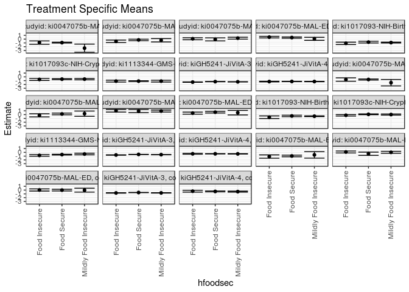

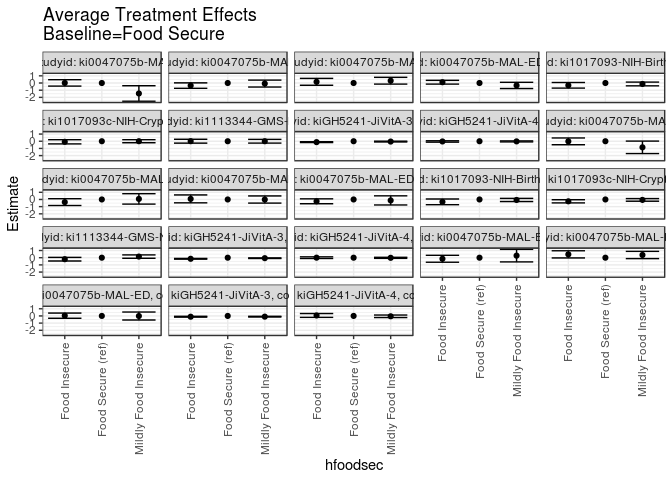

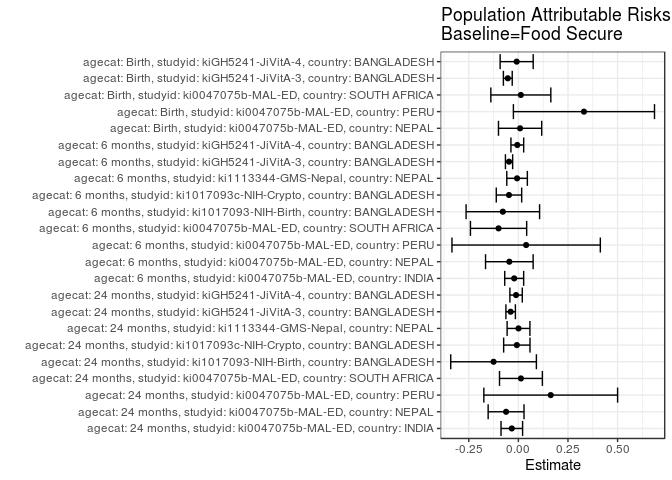

## Results Table

### Parameter: TSM

| agecat | studyid | country | intervention_level | baseline_level | estimate | ci_lower | ci_upper |
| --- | --- | --- | --- | --- | --- | --- | --- |
| Birth | ki0047075b-MAL-ED | NEPAL | Food Secure | NA | -0.9589333 | -1.1679562 | -0.7499105 |
| Birth | ki0047075b-MAL-ED | NEPAL | Mildly Food Insecure | NA | -0.6700000 | -1.5216911 | 0.1816911 |
| Birth | ki0047075b-MAL-ED | NEPAL | Food Insecure | NA | -1.1066667 | -1.5431611 | -0.6701723 |
| Birth | ki0047075b-MAL-ED | PERU | Food Secure | NA | -0.3700000 | -0.7971079 | 0.0571079 |
| Birth | ki0047075b-MAL-ED | PERU | Mildly Food Insecure | NA | 0.0091667 | -0.2577715 | 0.2761048 |
| Birth | ki0047075b-MAL-ED | PERU | Food Insecure | NA | 0.0954545 | -0.1613595 | 0.3522686 |
| Birth | ki0047075b-MAL-ED | SOUTH AFRICA | Food Secure | NA | -0.0086792 | -0.2296074 | 0.2122490 |
| Birth | ki0047075b-MAL-ED | SOUTH AFRICA | Mildly Food Insecure | NA | -0.0200000 | -0.5307773 | 0.4907773 |
| Birth | ki0047075b-MAL-ED | SOUTH AFRICA | Food Insecure | NA | 0.0281429 | -0.2597067 | 0.3159924 |
| Birth | kiGH5241-JiVitA-3 | BANGLADESH | Food Secure | NA | -0.6459530 | -0.6788099 | -0.6130961 |
| Birth | kiGH5241-JiVitA-3 | BANGLADESH | Mildly Food Insecure | NA | -0.7456568 | -0.7846968 | -0.7066167 |
| Birth | kiGH5241-JiVitA-3 | BANGLADESH | Food Insecure | NA | -0.7558687 | -0.8060171 | -0.7057203 |
| Birth | kiGH5241-JiVitA-4 | BANGLADESH | Food Secure | NA | -0.3593713 | -0.4749953 | -0.2437473 |
| Birth | kiGH5241-JiVitA-4 | BANGLADESH | Mildly Food Insecure | NA | -0.4081600 | -0.5374997 | -0.2788203 |
| Birth | kiGH5241-JiVitA-4 | BANGLADESH | Food Insecure | NA | -0.2936458 | -0.5362401 | -0.0510515 |
| 6 months | ki0047075b-MAL-ED | INDIA | Food Secure | NA | -0.6943421 | -0.8349961 | -0.5536881 |
| 6 months | ki0047075b-MAL-ED | INDIA | Mildly Food Insecure | NA | -1.5420000 | -2.3989104 | -0.6850896 |
| 6 months | ki0047075b-MAL-ED | INDIA | Food Insecure | NA | -0.7090196 | -1.1598311 | -0.2582081 |
| 6 months | ki0047075b-MAL-ED | NEPAL | Food Secure | NA | 0.1744858 | -0.0459177 | 0.3948894 |
| 6 months | ki0047075b-MAL-ED | NEPAL | Mildly Food Insecure | NA | 0.2512222 | -0.4390110 | 0.9414555 |
| 6 months | ki0047075b-MAL-ED | NEPAL | Food Insecure | NA | -0.1931579 | -0.6112605 | 0.2249447 |
| 6 months | ki0047075b-MAL-ED | PERU | Food Secure | NA | 0.9400000 | 0.5127971 | 1.3672029 |
| 6 months | ki0047075b-MAL-ED | PERU | Mildly Food Insecure | NA | 0.9332143 | 0.6768811 | 1.1895475 |
| 6 months | ki0047075b-MAL-ED | PERU | Food Insecure | NA | 1.0208929 | 0.6717324 | 1.3700533 |
| 6 months | ki0047075b-MAL-ED | SOUTH AFRICA | Food Secure | NA | 0.6421964 | 0.4279639 | 0.8564289 |
| 6 months | ki0047075b-MAL-ED | SOUTH AFRICA | Mildly Food Insecure | NA | 0.5123148 | -0.0861454 | 1.1107750 |
| 6 months | ki0047075b-MAL-ED | SOUTH AFRICA | Food Insecure | NA | 0.3897119 | 0.1232743 | 0.6561495 |
| 6 months | ki1017093-NIH-Birth | BANGLADESH | Food Secure | NA | -0.3605625 | -0.5544737 | -0.1666513 |
| 6 months | ki1017093-NIH-Birth | BANGLADESH | Mildly Food Insecure | NA | -0.4295453 | -0.5323959 | -0.3266947 |
| 6 months | ki1017093-NIH-Birth | BANGLADESH | Food Insecure | NA | -0.6930000 | -1.0413123 | -0.3446877 |
| 6 months | ki1017093c-NIH-Crypto | BANGLADESH | Food Secure | NA | 0.0772014 | -0.0274914 | 0.1818942 |
| 6 months | ki1017093c-NIH-Crypto | BANGLADESH | Mildly Food Insecure | NA | 0.0163725 | -0.1308515 | 0.1635966 |
| 6 months | ki1017093c-NIH-Crypto | BANGLADESH | Food Insecure | NA | -0.1788690 | -0.3732511 | 0.0155130 |
| 6 months | ki1113344-GMS-Nepal | NEPAL | Food Secure | NA | -0.5962194 | -0.7011920 | -0.4912469 |
| 6 months | ki1113344-GMS-Nepal | NEPAL | Mildly Food Insecure | NA | -0.4403289 | -0.6485970 | -0.2320609 |
| 6 months | ki1113344-GMS-Nepal | NEPAL | Food Insecure | NA | -0.8052703 | -1.0315347 | -0.5790058 |
| 6 months | kiGH5241-JiVitA-3 | BANGLADESH | Food Secure | NA | -0.5461279 | -0.5738473 | -0.5184085 |
| 6 months | kiGH5241-JiVitA-3 | BANGLADESH | Mildly Food Insecure | NA | -0.6116959 | -0.6417186 | -0.5816732 |
| 6 months | kiGH5241-JiVitA-3 | BANGLADESH | Food Insecure | NA | -0.6984305 | -0.7418746 | -0.6549864 |
| 6 months | kiGH5241-JiVitA-4 | BANGLADESH | Food Secure | NA | -0.3841391 | -0.4325457 | -0.3357325 |
| 6 months | kiGH5241-JiVitA-4 | BANGLADESH | Mildly Food Insecure | NA | -0.4003935 | -0.4584618 | -0.3423253 |
| 6 months | kiGH5241-JiVitA-4 | BANGLADESH | Food Insecure | NA | -0.3807154 | -0.4897478 | -0.2716830 |
| 24 months | ki0047075b-MAL-ED | INDIA | Food Secure | NA | -0.9263947 | -1.0447734 | -0.8080160 |
| 24 months | ki0047075b-MAL-ED | INDIA | Mildly Food Insecure | NA | -2.3840000 | -3.4554070 | -1.3125930 |
| 24 months | ki0047075b-MAL-ED | INDIA | Food Insecure | NA | -0.9111765 | -1.3418053 | -0.4805476 |
| 24 months | ki0047075b-MAL-ED | NEPAL | Food Secure | NA | -0.2137766 | -0.4104542 | -0.0170990 |
| 24 months | ki0047075b-MAL-ED | NEPAL | Mildly Food Insecure | NA | -0.2906667 | -0.7322845 | 0.1509512 |
| 24 months | ki0047075b-MAL-ED | NEPAL | Food Insecure | NA | -0.5707895 | -0.8927455 | -0.2488334 |
| 24 months | ki0047075b-MAL-ED | PERU | Food Secure | NA | -0.0650000 | -0.4644175 | 0.3344175 |
| 24 months | ki0047075b-MAL-ED | PERU | Mildly Food Insecure | NA | 0.2540741 | 0.0038590 | 0.5042891 |
| 24 months | ki0047075b-MAL-ED | PERU | Food Insecure | NA | 0.0984259 | -0.1657321 | 0.3625840 |
| 24 months | ki0047075b-MAL-ED | SOUTH AFRICA | Food Secure | NA | 0.4135659 | 0.2501149 | 0.5770169 |
| 24 months | ki0047075b-MAL-ED | SOUTH AFRICA | Mildly Food Insecure | NA | 0.0797222 | -0.3228365 | 0.4822809 |
| 24 months | ki0047075b-MAL-ED | SOUTH AFRICA | Food Insecure | NA | 0.5240741 | 0.3171606 | 0.7309876 |
| 24 months | ki1017093-NIH-Birth | BANGLADESH | Food Secure | NA | -0.7864461 | -1.0193808 | -0.5535114 |
| 24 months | ki1017093-NIH-Birth | BANGLADESH | Mildly Food Insecure | NA | -0.9180505 | -1.0321622 | -0.8039387 |
| 24 months | ki1017093-NIH-Birth | BANGLADESH | Food Insecure | NA | -1.1053030 | -1.4148575 | -0.7957485 |
| 24 months | ki1017093c-NIH-Crypto | BANGLADESH | Food Secure | NA | -0.6024850 | -0.7257444 | -0.4792256 |
| 24 months | ki1017093c-NIH-Crypto | BANGLADESH | Mildly Food Insecure | NA | -0.5987903 | -0.7700446 | -0.4275361 |
| 24 months | ki1017093c-NIH-Crypto | BANGLADESH | Food Insecure | NA | -0.6828571 | -0.9480378 | -0.4176765 |
| 24 months | ki1113344-GMS-Nepal | NEPAL | Food Secure | NA | -1.1264655 | -1.2298887 | -1.0230423 |
| 24 months | ki1113344-GMS-Nepal | NEPAL | Mildly Food Insecure | NA | -1.1261594 | -1.3657302 | -0.8865886 |
| 24 months | ki1113344-GMS-Nepal | NEPAL | Food Insecure | NA | -1.1220000 | -1.3707063 | -0.8732937 |
| 24 months | kiGH5241-JiVitA-3 | BANGLADESH | Food Secure | NA | -1.2598418 | -1.2934515 | -1.2262322 |
| 24 months | kiGH5241-JiVitA-3 | BANGLADESH | Mildly Food Insecure | NA | -1.3052234 | -1.3457662 | -1.2646806 |
| 24 months | kiGH5241-JiVitA-3 | BANGLADESH | Food Insecure | NA | -1.3828924 | -1.4302599 | -1.3355249 |
| 24 months | kiGH5241-JiVitA-4 | BANGLADESH | Food Secure | NA | -1.2127585 | -1.2572363 | -1.1682806 |
| 24 months | kiGH5241-JiVitA-4 | BANGLADESH | Mildly Food Insecure | NA | -1.2339023 | -1.2895279 | -1.1782766 |
| 24 months | kiGH5241-JiVitA-4 | BANGLADESH | Food Insecure | NA | -1.2432730 | -1.3240021 | -1.1625440 |

### Parameter: E(Y)

| agecat | studyid | country | intervention_level | baseline_level | estimate | ci_lower | ci_upper |
| --- | --- | --- | --- | --- | --- | --- | --- |
| Birth | ki0047075b-MAL-ED | NEPAL | NA | NA | -0.9503125 | -1.1412124 | -0.7594126 |
| Birth | ki0047075b-MAL-ED | PERU | NA | NA | -0.0395238 | -0.2249300 | 0.1458824 |
| Birth | ki0047075b-MAL-ED | SOUTH AFRICA | NA | NA | 0.0036788 | -0.1626160 | 0.1699735 |
| Birth | kiGH5241-JiVitA-3 | BANGLADESH | NA | NA | -0.6992565 | -0.7232731 | -0.6752399 |
| Birth | kiGH5241-JiVitA-4 | BANGLADESH | NA | NA | -0.3680294 | -0.4489214 | -0.2871374 |
| 6 months | ki0047075b-MAL-ED | INDIA | NA | NA | -0.7155110 | -0.8495147 | -0.5815073 |
| 6 months | ki0047075b-MAL-ED | NEPAL | NA | NA | 0.1289063 | -0.0638567 | 0.3216692 |
| 6 months | ki0047075b-MAL-ED | PERU | NA | NA | 0.9790991 | 0.7644567 | 1.1937415 |
| 6 months | ki0047075b-MAL-ED | SOUTH AFRICA | NA | NA | 0.5422442 | 0.3806254 | 0.7038629 |
| 6 months | ki1017093-NIH-Birth | BANGLADESH | NA | NA | -0.4389101 | -0.5279432 | -0.3498771 |
| 6 months | ki1017093c-NIH-Crypto | BANGLADESH | NA | NA | 0.0297622 | -0.0491685 | 0.1086930 |
| 6 months | ki1113344-GMS-Nepal | NEPAL | NA | NA | -0.6028654 | -0.6902793 | -0.5154516 |
| 6 months | kiGH5241-JiVitA-3 | BANGLADESH | NA | NA | -0.5932301 | -0.6127836 | -0.5736767 |
| 6 months | kiGH5241-JiVitA-4 | BANGLADESH | NA | NA | -0.3895527 | -0.4270314 | -0.3520739 |
| 24 months | ki0047075b-MAL-ED | INDIA | NA | NA | -0.9595519 | -1.0781202 | -0.8409836 |
| 24 months | ki0047075b-MAL-ED | NEPAL | NA | NA | -0.2757812 | -0.4379560 | -0.1136065 |
| 24 months | ki0047075b-MAL-ED | PERU | NA | NA | 0.0979907 | -0.0798724 | 0.2758537 |
| 24 months | ki0047075b-MAL-ED | SOUTH AFRICA | NA | NA | 0.4264693 | 0.3032402 | 0.5496984 |
| 24 months | ki1017093-NIH-Birth | BANGLADESH | NA | NA | -0.9115790 | -1.0095022 | -0.8136559 |
| 24 months | ki1017093c-NIH-Crypto | BANGLADESH | NA | NA | -0.6103502 | -0.7050157 | -0.5156847 |
| 24 months | ki1113344-GMS-Nepal | NEPAL | NA | NA | -1.1257803 | -1.2146168 | -1.0369438 |
| 24 months | kiGH5241-JiVitA-3 | BANGLADESH | NA | NA | -1.2988352 | -1.3224626 | -1.2752078 |
| 24 months | kiGH5241-JiVitA-4 | BANGLADESH | NA | NA | -1.2243590 | -1.2566569 | -1.1920612 |

### Parameter: ATE

| agecat | studyid | country | intervention_level | baseline_level | estimate | ci_lower | ci_upper |
| --- | --- | --- | --- | --- | --- | --- | --- |
| Birth | ki0047075b-MAL-ED | NEPAL | Food Secure | Food Secure | 0.0000000 | 0.0000000 | 0.0000000 |
| Birth | ki0047075b-MAL-ED | NEPAL | Mildly Food Insecure | Food Secure | 0.2889333 | -0.5880320 | 1.1658987 |
| Birth | ki0047075b-MAL-ED | NEPAL | Food Insecure | Food Secure | -0.1477333 | -0.6316940 | 0.3362273 |
| Birth | ki0047075b-MAL-ED | PERU | Food Secure | Food Secure | 0.0000000 | 0.0000000 | 0.0000000 |
| Birth | ki0047075b-MAL-ED | PERU | Mildly Food Insecure | Food Secure | 0.3791667 | -0.1244971 | 0.8828304 |
| Birth | ki0047075b-MAL-ED | PERU | Food Insecure | Food Secure | 0.4654545 | -0.0329174 | 0.9638265 |
| Birth | ki0047075b-MAL-ED | SOUTH AFRICA | Food Secure | Food Secure | 0.0000000 | 0.0000000 | 0.0000000 |
| Birth | ki0047075b-MAL-ED | SOUTH AFRICA | Mildly Food Insecure | Food Secure | -0.0113208 | -0.5678302 | 0.5451887 |
| Birth | ki0047075b-MAL-ED | SOUTH AFRICA | Food Insecure | Food Secure | 0.0368221 | -0.3260368 | 0.3996810 |
| Birth | kiGH5241-JiVitA-3 | BANGLADESH | Food Secure | Food Secure | 0.0000000 | 0.0000000 | 0.0000000 |
| Birth | kiGH5241-JiVitA-3 | BANGLADESH | Mildly Food Insecure | Food Secure | -0.0997038 | -0.1484792 | -0.0509285 |
| Birth | kiGH5241-JiVitA-3 | BANGLADESH | Food Insecure | Food Secure | -0.1099158 | -0.1674794 | -0.0523521 |
| Birth | kiGH5241-JiVitA-4 | BANGLADESH | Food Secure | Food Secure | 0.0000000 | 0.0000000 | 0.0000000 |
| Birth | kiGH5241-JiVitA-4 | BANGLADESH | Mildly Food Insecure | Food Secure | -0.0487887 | -0.2237274 | 0.1261499 |
| Birth | kiGH5241-JiVitA-4 | BANGLADESH | Food Insecure | Food Secure | 0.0657254 | -0.2023740 | 0.3338249 |
| 6 months | ki0047075b-MAL-ED | INDIA | Food Secure | Food Secure | 0.0000000 | 0.0000000 | 0.0000000 |
| 6 months | ki0047075b-MAL-ED | INDIA | Mildly Food Insecure | Food Secure | -0.8476579 | -1.7160351 | 0.0207193 |
| 6 months | ki0047075b-MAL-ED | INDIA | Food Insecure | Food Secure | -0.0146775 | -0.4869217 | 0.4575667 |
| 6 months | ki0047075b-MAL-ED | NEPAL | Food Secure | Food Secure | 0.0000000 | 0.0000000 | 0.0000000 |
| 6 months | ki0047075b-MAL-ED | NEPAL | Mildly Food Insecure | Food Secure | 0.0767364 | -0.6478322 | 0.8013050 |
| 6 months | ki0047075b-MAL-ED | NEPAL | Food Insecure | Food Secure | -0.3676437 | -0.8402826 | 0.1049952 |
| 6 months | ki0047075b-MAL-ED | PERU | Food Secure | Food Secure | 0.0000000 | 0.0000000 | 0.0000000 |
| 6 months | ki0047075b-MAL-ED | PERU | Mildly Food Insecure | Food Secure | -0.0067857 | -0.5049915 | 0.4914201 |
| 6 months | ki0047075b-MAL-ED | PERU | Food Insecure | Food Secure | 0.0808929 | -0.4708456 | 0.6326313 |
| 6 months | ki0047075b-MAL-ED | SOUTH AFRICA | Food Secure | Food Secure | 0.0000000 | 0.0000000 | 0.0000000 |
| 6 months | ki0047075b-MAL-ED | SOUTH AFRICA | Mildly Food Insecure | Food Secure | -0.1298816 | -0.7655310 | 0.5057678 |
| 6 months | ki0047075b-MAL-ED | SOUTH AFRICA | Food Insecure | Food Secure | -0.2524844 | -0.5943683 | 0.0893994 |
| 6 months | ki1017093-NIH-Birth | BANGLADESH | Food Secure | Food Secure | 0.0000000 | 0.0000000 | 0.0000000 |
| 6 months | ki1017093-NIH-Birth | BANGLADESH | Mildly Food Insecure | Food Secure | -0.0689828 | -0.2884818 | 0.1505162 |
| 6 months | ki1017093-NIH-Birth | BANGLADESH | Food Insecure | Food Secure | -0.3324375 | -0.7310890 | 0.0662140 |
| 6 months | ki1017093c-NIH-Crypto | BANGLADESH | Food Secure | Food Secure | 0.0000000 | 0.0000000 | 0.0000000 |
| 6 months | ki1017093c-NIH-Crypto | BANGLADESH | Mildly Food Insecure | Food Secure | -0.0608289 | -0.2414819 | 0.1198242 |
| 6 months | ki1017093c-NIH-Crypto | BANGLADESH | Food Insecure | Food Secure | -0.2560705 | -0.4768531 | -0.0352878 |
| 6 months | ki1113344-GMS-Nepal | NEPAL | Food Secure | Food Secure | 0.0000000 | 0.0000000 | 0.0000000 |
| 6 months | ki1113344-GMS-Nepal | NEPAL | Mildly Food Insecure | Food Secure | 0.1558905 | -0.0773365 | 0.3891174 |
| 6 months | ki1113344-GMS-Nepal | NEPAL | Food Insecure | Food Secure | -0.2090509 | -0.4584799 | 0.0403782 |
| 6 months | kiGH5241-JiVitA-3 | BANGLADESH | Food Secure | Food Secure | 0.0000000 | 0.0000000 | 0.0000000 |
| 6 months | kiGH5241-JiVitA-3 | BANGLADESH | Mildly Food Insecure | Food Secure | -0.0655680 | -0.1054453 | -0.0256907 |
| 6 months | kiGH5241-JiVitA-3 | BANGLADESH | Food Insecure | Food Secure | -0.1523026 | -0.2018357 | -0.1027695 |
| 6 months | kiGH5241-JiVitA-4 | BANGLADESH | Food Secure | Food Secure | 0.0000000 | 0.0000000 | 0.0000000 |
| 6 months | kiGH5241-JiVitA-4 | BANGLADESH | Mildly Food Insecure | Food Secure | -0.0162545 | -0.0877010 | 0.0551921 |
| 6 months | kiGH5241-JiVitA-4 | BANGLADESH | Food Insecure | Food Secure | 0.0034236 | -0.1123099 | 0.1191572 |
| 24 months | ki0047075b-MAL-ED | INDIA | Food Secure | Food Secure | 0.0000000 | 0.0000000 | 0.0000000 |
| 24 months | ki0047075b-MAL-ED | INDIA | Mildly Food Insecure | Food Secure | -1.4576053 | -2.5355322 | -0.3796783 |
| 24 months | ki0047075b-MAL-ED | INDIA | Food Insecure | Food Secure | 0.0152183 | -0.4313853 | 0.4618218 |
| 24 months | ki0047075b-MAL-ED | NEPAL | Food Secure | Food Secure | 0.0000000 | 0.0000000 | 0.0000000 |
| 24 months | ki0047075b-MAL-ED | NEPAL | Mildly Food Insecure | Food Secure | -0.0768901 | -0.5603241 | 0.4065439 |
| 24 months | ki0047075b-MAL-ED | NEPAL | Food Insecure | Food Secure | -0.3570129 | -0.7342897 | 0.0202639 |
| 24 months | ki0047075b-MAL-ED | PERU | Food Secure | Food Secure | 0.0000000 | 0.0000000 | 0.0000000 |
| 24 months | ki0047075b-MAL-ED | PERU | Mildly Food Insecure | Food Secure | 0.3190741 | -0.1522452 | 0.7903934 |
| 24 months | ki0047075b-MAL-ED | PERU | Food Insecure | Food Secure | 0.1634259 | -0.3154413 | 0.6422931 |
| 24 months | ki0047075b-MAL-ED | SOUTH AFRICA | Food Secure | Food Secure | 0.0000000 | 0.0000000 | 0.0000000 |
| 24 months | ki0047075b-MAL-ED | SOUTH AFRICA | Mildly Food Insecure | Food Secure | -0.3338437 | -0.7683201 | 0.1006327 |
| 24 months | ki0047075b-MAL-ED | SOUTH AFRICA | Food Insecure | Food Secure | 0.1105082 | -0.1531762 | 0.3741925 |
| 24 months | ki1017093-NIH-Birth | BANGLADESH | Food Secure | Food Secure | 0.0000000 | 0.0000000 | 0.0000000 |
| 24 months | ki1017093-NIH-Birth | BANGLADESH | Mildly Food Insecure | Food Secure | -0.1316044 | -0.3909884 | 0.1277796 |
| 24 months | ki1017093-NIH-Birth | BANGLADESH | Food Insecure | Food Secure | -0.3188570 | -0.7062619 | 0.0685479 |
| 24 months | ki1017093c-NIH-Crypto | BANGLADESH | Food Secure | Food Secure | 0.0000000 | 0.0000000 | 0.0000000 |
| 24 months | ki1017093c-NIH-Crypto | BANGLADESH | Mildly Food Insecure | Food Secure | 0.0036947 | -0.2073051 | 0.2146945 |
| 24 months | ki1017093c-NIH-Crypto | BANGLADESH | Food Insecure | Food Secure | -0.0803721 | -0.3727993 | 0.2120551 |
| 24 months | ki1113344-GMS-Nepal | NEPAL | Food Secure | Food Secure | 0.0000000 | 0.0000000 | 0.0000000 |
| 24 months | ki1113344-GMS-Nepal | NEPAL | Mildly Food Insecure | Food Secure | 0.0003061 | -0.2606355 | 0.2612477 |
| 24 months | ki1113344-GMS-Nepal | NEPAL | Food Insecure | Food Secure | 0.0044655 | -0.2648878 | 0.2738188 |
| 24 months | kiGH5241-JiVitA-3 | BANGLADESH | Food Secure | Food Secure | 0.0000000 | 0.0000000 | 0.0000000 |
| 24 months | kiGH5241-JiVitA-3 | BANGLADESH | Mildly Food Insecure | Food Secure | -0.0453815 | -0.0971887 | 0.0064256 |
| 24 months | kiGH5241-JiVitA-3 | BANGLADESH | Food Insecure | Food Secure | -0.1230506 | -0.1798804 | -0.0662207 |
| 24 months | kiGH5241-JiVitA-4 | BANGLADESH | Food Secure | Food Secure | 0.0000000 | 0.0000000 | 0.0000000 |
| 24 months | kiGH5241-JiVitA-4 | BANGLADESH | Mildly Food Insecure | Food Secure | -0.0211438 | -0.0916223 | 0.0493346 |
| 24 months | kiGH5241-JiVitA-4 | BANGLADESH | Food Insecure | Food Secure | -0.0305145 | -0.1229812 | 0.0619521 |

### Parameter: PAR

| agecat | studyid | country | intervention_level | baseline_level | estimate | ci_lower | ci_upper |
| --- | --- | --- | --- | --- | --- | --- | --- |
| Birth | ki0047075b-MAL-ED | NEPAL | Food Secure | NA | 0.0086208 | -0.1003141 | 0.1175558 |
| Birth | ki0047075b-MAL-ED | PERU | Food Secure | NA | 0.3304762 | -0.0251285 | 0.6860809 |
| Birth | ki0047075b-MAL-ED | SOUTH AFRICA | Food Secure | NA | 0.0123580 | -0.1388004 | 0.1635164 |
| Birth | kiGH5241-JiVitA-3 | BANGLADESH | Food Secure | NA | -0.0533035 | -0.0755743 | -0.0310328 |
| Birth | kiGH5241-JiVitA-4 | BANGLADESH | Food Secure | NA | -0.0086582 | -0.0919971 | 0.0746808 |
| 6 months | ki0047075b-MAL-ED | INDIA | Food Secure | NA | -0.0211689 | -0.0689128 | 0.0265750 |
| 6 months | ki0047075b-MAL-ED | NEPAL | Food Secure | NA | -0.0455796 | -0.1655243 | 0.0743652 |
| 6 months | ki0047075b-MAL-ED | PERU | Food Secure | NA | 0.0390991 | -0.3347842 | 0.4129824 |
| 6 months | ki0047075b-MAL-ED | SOUTH AFRICA | Food Secure | NA | -0.0999522 | -0.2416623 | 0.0417578 |
| 6 months | ki1017093-NIH-Birth | BANGLADESH | Food Secure | NA | -0.0783476 | -0.2635613 | 0.1068660 |
| 6 months | ki1017093c-NIH-Crypto | BANGLADESH | Food Secure | NA | -0.0474392 | -0.1114647 | 0.0165864 |
| 6 months | ki1113344-GMS-Nepal | NEPAL | Food Secure | NA | -0.0066460 | -0.0584879 | 0.0451958 |
| 6 months | kiGH5241-JiVitA-3 | BANGLADESH | Food Secure | NA | -0.0471022 | -0.0652966 | -0.0289079 |
| 6 months | kiGH5241-JiVitA-4 | BANGLADESH | Food Secure | NA | -0.0054136 | -0.0375357 | 0.0267085 |
| 24 months | ki0047075b-MAL-ED | INDIA | Food Secure | NA | -0.0331571 | -0.0875022 | 0.0211879 |
| 24 months | ki0047075b-MAL-ED | NEPAL | Food Secure | NA | -0.0620047 | -0.1523839 | 0.0283746 |
| 24 months | ki0047075b-MAL-ED | PERU | Food Secure | NA | 0.1629907 | -0.1741130 | 0.5000943 |
| 24 months | ki0047075b-MAL-ED | SOUTH AFRICA | Food Secure | NA | 0.0129034 | -0.0951249 | 0.1209317 |
| 24 months | ki1017093-NIH-Birth | BANGLADESH | Food Secure | NA | -0.1251330 | -0.3410183 | 0.0907523 |
| 24 months | ki1017093c-NIH-Crypto | BANGLADESH | Food Secure | NA | -0.0078652 | -0.0742700 | 0.0585397 |
| 24 months | ki1113344-GMS-Nepal | NEPAL | Food Secure | NA | 0.0006852 | -0.0567734 | 0.0581438 |
| 24 months | kiGH5241-JiVitA-3 | BANGLADESH | Food Secure | NA | -0.0389933 | -0.0628759 | -0.0151107 |
| 24 months | kiGH5241-JiVitA-4 | BANGLADESH | Food Secure | NA | -0.0116006 | -0.0428434 | 0.0196423 |